# Feynman-Kac

[Table of Contents](https://binaria010.github.io/PricingTheory/)

## Relation between Partial Differential Equations and Conditional Expectations.

In this section we will see the Theorem (Feynman-Kac Theorem)linking both approaches to pricing. Rougly speaking, there is a partical differential equation for the price of a portfolio whose discounting is a Martingale process under the risk-neutral measure.

Let us first state the Markov property of a solution to an SDE.

Consider the solution of the SDE

$$ dX(t) = \beta(t, X(t))dt + \gamma(t, X(t))dW(t)~~ t\in[t_0,T] $$

such that $X(t_0)=x$ and let $h$ be any Borel-measurable function. Then the Markov property states as follows:

**Markov Property.** Let $X(t)$ for $t>0$ be a solution to the SDE given above with initial condition given at time $t_0=0$. Then for $t\in[0, T]$,

$$ \mathbb{E}\left[h(X(T))\vert \mathcal{F}(t)\right] = g(t, X(t)). $$

That is, the conditional expectation of $h(X(T))$, conditional on all history up to time $t$, is a function depending only on the present time $t$ and the value of the process at this time.

**Theorem. (Feynman-Kac)** Consider the SDE and the function $h$ as before. Fix $T>0$ and let $t\in[0,T]$ be given. Define the function

$$ g(t, x) = \mathbb{E}^{t,x}h(X(T)) $$

where the supra index in the expected value means the expectation of the random variable $h(X(T))$ when the process $X$ at time $t$ is $X(t)=x$. Then, the function $g$ satisfies the following PDE with terminal condition:

$$ \begin{align*} & g_t(t,x) +\beta(t, x)g_x(t, x) + \frac{1}{2}\gamma^2(t, x)g_{xx}(t,x) = 0 \\ & g(T, x) = h(x) \quad \forall x \end{align*} $$

*Proof.* Let $X(t)$ be the solution of the SDE starting at time zero. Note that the random process $g(t, X(t))$ is a Martingale for, by the Markov property $\mathbb{E}\left[h(X(T))\vert \mathcal{F}(s)\right] = g(s, X(s))$ and the *[tower property](https://proofwiki.org/wiki/Tower_Property_of_Conditional_Expectation)* of conditional expectations:

$$ \begin{align*} \mathbb{E}\left[g(t, X(t)) \vert \mathcal{F}(s)\right] =& \mathbb{E}\left[\mathbb{E}\left[h(X(T))\vert \mathcal{F}(t)\right] \vert\mathcal{F}(s)\right] \\ =& \mathbb{E}\left[h(X(T))\vert \mathcal{F}(s)\right] \\ =& g(s, X(s)). \end{align*} $$

Therefore the term multiplying $dt$ in the formula for $d(g(t,X(t)))$ must be zero. by the Ito formula:

$$\begin{align*} d(g(t,X(t))) =& g_t(t, X(t))dt + g_x(t, X(t))dX(t) + \frac{1}{2}g_{xx}dX(t)dX(t) \\ = & g_t(t, X(t))dt + \beta(t, X(t))g_x(t, X(t))dt + \gamma(t, X(t))g_x(t, X(t))dW(t) + \frac{1}{2}\gamma^2(t, X(t))g_{xx}(t, X(t))dt. \end{align*} $$

The, equating the coefficient of $dt$ to zero we get:

$$ g_t(t, X(t)) + \beta(t, X(t))g_x(t, X(t)) + \frac{1}{2}\gamma^2(t, X(t))g_{xx}(t, X(t)) =0 $$

along every path $X$. Therefore:

$$ g_t(t, x) + \beta(t, x)g_x(t, x) + \frac{1}{2}\gamma^2(t, x)g_{xx}(t, x) =0 $$

at every point $(t,x)$ that can be reached by $(t, X(t))$.

Note that so far, this Theorem does not include the case of Black Scholes model, this is because in that case we have that the discounted price (not the price) is what follows a Martingale process am the discounted price can't be seen as a function $h(X(t))$, rather as a function of both variables $t$ and $X(t)$. As a matter of fact the Balck-Sholes PDE has an extra term which is the function $g$ it self (with no derivatives). For this, we have the *Discounted Feynman-Kac* Theorem.

**Discounted Feynman-Kac.** Consider the SDE and the function $h$ as before. Define the function

$$ f(t, x) =\mathbb{E}^{t,x}\left[\frac{D(T)}{D(t)}h(X(T))\right] $$

where $D(t) = e^{-\int_0^t R(s)ds}$ is the discounting process and $R$ the interest rate process. Then the function $f$ satisfies the PDE with terminal condition

$$ \begin{align*} &f_t(t,x) +\beta(t,x)f_x(t,x) +\frac{1}{2}\gamma^2(t, x)f_{xx}(t,x) = R(t)f(t,x)\\ &f(T,x) = h(x) \end{align*} $$

The proof is as before, except that is the process $D(t)f(t,X(t))$ the one that is Martingale and not $f(t,X(t))$ itself. Therefore equating the coefficient of $dt$ in the expression $d(D(t)f(t, X(t)))$ we get the PDE.

Note that for the case of a sotck following a Geometric Brownian motion and with a constant interest rate $r$ we get the Black-Scholes PDE for the price of an option with payoff $h(S(T))$. In fact, under the risk-neutral measure the stocks follows the SDE

$$ dS(t) = rS(t)dt +\sigma S(t)d\widetilde{W}(t). $$

According to the risk-neutral pricing formula, the price at time $t$ of this option is:

$$ V(t) = \widetilde{\mathbb{E}}\left[e^{-r(T-t)}h(S(T))\vert \mathcal{F}(t) \right]. $$

Since the stock price is a Markov process and the payoff of the option depends only on the stock price then there is a function $v(t,x)$ such that $V(t) = v(t, S(t))$. This function satisfies the PDE in the Discounted Feynman-Kac Theorem:

$$ v_t(t, x) + rxv_x(t, x) + \frac{1}{2}\sigma^2x^2v_{xx}(t,x) = rv(t, x). $$

The solution to this PDE is the right price for a Eruopean call, European put, a forward contract or any other derivative security whose payoff is some function of the stock price at time $T$ with underlying asset following a Geometric Brownian motion.

In low dimensions, i.e when there are few underlying assets $S_i$, the Feynman-Kac Theorem has an advantage over the Monte Carlo simulation to estimate the price. This is, because in low dimensions is less computationally expensive to solve the PDE given by Feynman-Kac than to simulating the stock to estimate the function $V(t)$. Also, in a more general case for the stock price, such as a non constant volatility we don't have a closed form for the price (closed form for the Black-Scholes PDE), then in this case by solving numerically the PDE we can approximate the price of any option with payoff depending on $S(T)$ only.

### Examples.

#### 1. Price interest rate products

A zero-coupon bond is a contract promising to pay a certain "face" amount which we take to be 1 at a fixed maturity date $T$. Prior to that the bond makes no payments. The risk-neutral pricing formula says that the discounted price of this bond should be a Martingale under the risk-neutral measure. Then for $t\in[0,T]$, the price of the bond $B(t,T)$ satisfies: $$ D(t)B(t,T) = \widetilde{\mathbb{E}}\left[D(T)\vert\mathcal{F}(t) \right] $$

Then, the formula for the price is:

$$ B(t,T) = \widetilde{\mathbb{E}}\left[e^{-\int_{t}^TR(s)ds}\vert\mathcal{F}(t) \right] $$

with $B(T,T)$ the price at maturity date $T$ be equal to 1. If $R$ is th interest rate process (short interest rate), assume in this example that $R$ follows the Cox-Ingersoll-Ross (CIR) model:

$$ dR(t) = \kappa(\theta - R(t))dt +\sigma\sqrt{R(t)}d\widetilde{W}(t)\qquad \text{with } \kappa,\theta,\sigma>0. $$

Now, since $R$ is a Markov process, then the price $B$ must be of the form: $B(t,T) = f(t, R(t))$ for $f$ some function satisfying the *Discounted Feynman-Kac* PDE:

$$ \begin{align*} &f_t(t, r) +\kappa(\theta - r)f_r(t, r) + \frac{1}{2}\sigma^2r f_{rr}(t,r) - rf(t,r) = 0\\ &f(T,r) = 1\quad \forall r>0 \end{align*} $$

Let us compute (approximately) the price of this bond for $t\in[0,T]$ by means of numerically solving the PDE and by Monte Carlo method to estimate the expected value: $$ \begin{align*} & - g_t(t, r) +\kappa(\theta - r)g_r(t, r) + \frac{1}{2}\sigma^2r g_{rr}(t,r) - rg(t,r) = 0\\ &g(0,r) = 1\quad \forall r>0 \end{align*} $$

$$ \begin{align*} &g_t(t, r) = \kappa(\theta - r)g_r(t, r) + \frac{1}{2}\sigma^2r g_{rr}(t,r) - rg(t,r) \\ &g(0,r) = 1\quad \forall r>0\\ &g(t, r_{max}) = e^{-r_{max}t} \quad \forall t>0 \\ &\frac{\partial g}{\partial t}(t, 0) - \kappa\theta\frac{\partial g}{\partial r}(t, 0) = 0 \quad \forall t \\ \end{align*} $$

The finite-difference method to solve numerically this pde is:

Consider a uniform grid in time and space (variables $t$ and $r$ respectively), for instances take $N+1$ points equally spaced in $[0,T]$ and take $M+1$ equally spaced in $[r_{min}, r_{max}]$ then the steps in each grid are respectively:

$$ \Delta\tau = \frac{T}{N}\qquad \Delta r = \frac{r_{max}-r_{min}}{M} $$

then the nodes in each grid are:

$$ \begin{align*} \tau_n &:=n\Delta\tau \qquad n=0,1,\dots, N\\ r_k &:= r_{min} + k\Delta r \qquad k=0,1,\dots, M \end{align*} $$

If we denote by $G_k^n$ the value of the solution $g$ at nodes $(\tau_n, r_k)$ and use the centered differences to approximate the first and second partial derivatives of $g$ w.r.t the variable $r$ we get:

$$ \begin{align*} \frac{\partial g}{\partial r} &\approx \frac{g(\tau_n, r_{k+1}) - g(\tau_n, r_{k-1})}{2\Delta r} = \frac{G_{k+1}^n - G_{k-1}^n}{2\Delta r}\\ \frac{\partial^2 g}{\partial r^2} &\approx \frac{g(\tau_n, r_{k+1}) - 2g(\tau_n, r_{k}) + g(\tau_n, r_{k-1})}{\Delta r^2} = \frac{G_{k+1}^n - 2G_{k}^n + G_{k-1}^n}{\Delta r^2} \end{align*} $$

For the time derivative we can use the formward of backward finite differences:

$$ \begin{align*} \text{forward}\qquad \frac{\partial g}{\partial t} &\approx \frac{g(\tau_{n+1}, r_{k}) - g(\tau_n, r_{k})}{\Delta\tau} = \frac{G_{k}^{n+1} - G_{k}^n}{\Delta\tau}\\ \text{backward}\qquad\frac{\partial g}{\partial t} &\approx \frac{g(\tau_{n}, r_{k}) -g(\tau_{n-1}, r_{k})}{\Delta \tau} = \frac{G_{k}^n -G_{k}^{n-1}}{\Delta\tau} \end{align*} $$

In this type of problems it can be shown that the explicit scheme (the one with forward difference in time) is *unstable* , therefore we use the implicit scheme. Then, replacing the above expressions in the pde we get:

$$ \frac{G_{k}^{n} - G_{k}^{n-1}}{\Delta\tau} = \kappa(\theta - r_{k})\frac{G_{k+1}^n - G_{k-1}^n}{2\Delta r} +\frac{1}{2}\sigma^2r_k \frac{G_{k+1}^n - 2G_{k}^n + G_{k-1}^n}{\Delta r^2} -r_kG_{k}^n $$

Then, solving for $G_{k}^{n-1}$ and regrouping by the indexes $k-1, k, k+1$ we get:

$$ G_k^{n-1} = -\left(\frac{\Delta\tau}{2\Delta r^2}\sigma^2r_k - \frac{\Delta\tau}{2\Delta r}\kappa(\theta - r_k)\right)G_{k-1}^{n} + \left(1 +\frac{\Delta\tau}{\Delta r^2}\sigma^2r_k + \Delta\tau r_k\right)G_{k}^n - \left(\frac{\Delta\tau}{2\Delta r}\kappa(\theta - r_k) +\frac{\Delta\tau}{2\Delta r^2}\sigma^2 r_k\right)G_{k+1}^n $$

Defining the matrices:

$$ \begin{align*} A_{k}^n &:= \frac{\Delta\tau}{2\Delta r^2}\sigma^2r_k - \frac{\Delta\tau}{2\Delta r}\kappa(\theta - r_k)\\ B_{k}^n &:= \frac{\Delta\tau}{\Delta r^2}\sigma^2r_k +\Delta\tau r_k\\ C_{k}^n &:= \frac{\Delta\tau}{2\Delta r}\kappa(\theta - r_k) +\frac{\Delta\tau}{2\Delta r^2}\sigma^2 r_k \qquad k=1,2,\dots, M-1\quad n=0,1,\dots, N \end{align*} $$

The discretization for the boundary conditions is: $$ \frac{G_{0}^{n}- G_{0}^{n-1}}{\Delta\tau} - \kappa\theta\frac{G_{1}^{n} - G_{0}^{n}}{\Delta r} = 0 $$ then,

$$ G_0^{n-1} = \left(1 + \frac{\Delta \tau}{\Delta r}\kappa\theta\right)G_{0} ^{n} - \frac{\Delta \tau}{\Delta r}\kappa\theta G_{1}^{n} $$

Then, the iterative method is:

$$ \begin{align*} & G_{k}^{n-1} = -A_{k}^n G_{k-1}^n + (1+B_{k}^n)G_{k}^n - C_{k}^n G_{k+1}^n\quad \text{for } k=1,2,\dots, M-1\\ & G_{0}^{n-1} = \left(1 +\frac{\Delta \tau}{\Delta r}\kappa\theta\right)G_{0}^{n} - \frac{\Delta \tau}{\Delta r}\kappa\theta G_{1}^{n}\\ & G_{M}^{n-1} = e^{-r_{max}t_{n-1}} = e^{-r_{max}(t_{n} - \Delta\tau)} = e^{r_{max}\Delta\tau}G_{M}^{n}\qquad r_{max} = r_{M}\\ & G_{k}^{0} = 1 \quad \forall k=0,1,\dots, M\\ \end{align*} $$

Thus, we need to supply the datum at nodes $k=0, M$, that is the boundary conditions: $G_{0}^{0}=1$ and $G_{M}^{0} = e^{-r_{max}t_0} = 1$. The matrix representation of the scheme is:

$$ \begin{pmatrix} G^{n-1}_{0} \\ \\ G^{n-1}_{1} \\ \\ G^{n-1}_{2} \\ \\ \\ \\ \vdots \\ \\ \\ \\ \\ G^{n-1}_{M} \end{pmatrix} = \begin{pmatrix} 1 + \frac{\Delta \tau}{\Delta r}\kappa\theta& - \frac{\Delta \tau}{\Delta r}\kappa\theta & 0 &\cdots & & & & & & 0 & 0 \\ \\ -A_{1}^n & 1 + B_{1}^n & -C_{1}^n &0 &\cdots & & & & & 0 & 0 \\ \\ 0 & -A_{2}^n & 1 + B_{2}^n & -C_{2}^n &0 &\cdots & & & & 0 & 0 \\ \\ & & & & \ddots \\ \\ \\ \vdots \\ & & & & & & & -A_{M-2}^n & 1 + B_{M-2}^n & -C_{M-2}^n &0\\ \\ & & & & & & & 0 & -A_{M-1}^n & 1 + B_{M-1}^n & -C_{M-1}^n \\ \\ 0 & 0 & & \cdots & & & & 0 & 0 & 0&e^{r_{max}\Delta\tau} \end{pmatrix} \begin{pmatrix} G^{n}_{0} \\ \\ G^{n}_{1} \\ \\ G^{n}_{2} \\ \\ \\ \\ \vdots \\ \\ \\ \\ \\ G^{n}_{M} \end{pmatrix} $$

As can be seen in the matrix representation, the name *implicit* comes from the fact that we have implicitly define the solution at next step in terms of the previous one, thence we need to compute the inverse of the tridiagonal matrix in order to have the explicit formula.

```python
import numpy as np
import scipy.stats
import matplotlib.pyplot as plt
```

```python
def Thomas_Alg(d_0, d_sup, d_sub, b):

    """
    Implementation of Thomas algorithm to compute the inverse of a tridiagonal system of the form
    Ax = b with d_0, d_sup, d_sub the diagonals of the matrix A
    """

    m = len(d_0)
    d_00 = np.copy(d_0)
    b_new = np.copy(b)
    x = np.zeros(m)

    for k in range(1, m):
        # A = A = np.diag(d_00) + np.diag(d_sup, k=1) + np.diag(d_sub, k=-1)
        # print(A)
        d_00[k] = d_00[k] - d_sub[k-1]/d_00[k-1] * d_sup[k-1]
        b_new[k] = b_new[k] - d_sub[k-1]/d_00[k-1]*b_new[k-1]

    x[-1] = b_new[-1]/d_00[-1]

    for j in range(m-2, -1, -1):
        x[j] = (b_new[j] - d_sup[j]*x[j+1])/d_00[j]

    return x


def ZeroCouponBond_finite_diff(r_max,  T, kappa, theta, sigma, N, M):

    r_min = 0
    t_0 = 0
    delta_t = (T - t_0)/N
    delta_r = (r_max - r_min)/M
    grid_t = np.linspace(t_0, T, num= N+1)
    grid_r = np.linspace(r_min, r_max, num = M+1)

    G = np.zeros((M+1, N+1))
    G[:, 0] = 1

    # main diagonal
    d0 = np.hstack((1 + delta_t/delta_r * kappa* theta,1 +(delta_t/(delta_r**2) * sigma**2 + delta_t) * grid_r[1:M], np.exp(r_max*delta_t)))
    # sup diagonal
    d1 = np.hstack((-delta_t/delta_r *kappa*theta ,-0.5*delta_t/delta_r *(kappa*(theta - grid_r[1:M]) + 1/delta_r *sigma**2 * grid_r[1:M])))
    # sub diagonal
    d2 = np.hstack((-0.5 * delta_t/delta_r *(sigma**2 * grid_r[1:M]/delta_r - kappa*(theta - grid_r[1:M])), 0))

    for n in range(N):
        G[:, n+1] = Thomas_Alg(d_0= d0, d_sup = d1, d_sub=d2, b= G[:, n])


    return G, grid_t, grid_r
```

```python
def ZeroCouponBond_MC(r_init, t, T, kappa, theta, sigma, N_nodes = 101,Num_sim = 10**4):

    Z = scipy.stats.norm.rvs(loc=0, scale=1, size = Num_sim)
    grid_t = np.linspace(t, T, num=N_nodes)
    h = (T-t)/(N_nodes - 1)
    R = np.zeros((Num_sim, N_nodes))
    R[:, 0] = r_init

    for i in range(N_nodes-1):
        R[:, i+1] = R[:, i] + kappa * (theta - R[:,i])*h + sigma*np.sqrt(R[:, i])*np.sqrt(h)*Z +0.25*sigma**2*np.sqrt(h)*(Z**2 - 1)   #


    return np.mean(np.exp(-np.sum(R*h, axis = 1)))



def ZeroCouponBond_exact(r, t, T, kappa, theta, sigma):

    b = kappa
    a = kappa*theta
    gamma = 0.5*np.sqrt(b**2 + 2*sigma**2)
    denominator = gamma*np.cosh(gamma*(T-t)) + 0.5*b*np.sinh(gamma*(T-t))

    C = np.sinh(gamma*(T-t))/denominator
    A = -2*a/sigma**2 * np.log(gamma*np.exp(0.5*b*(T-t))/denominator)
    f = np.exp(-np.outer(r,C) - A)

    return f
```

```python
T = 1
kappa = 0.5
theta = 0.05
sigma = 0.01   #2*kappa*theta > sigma^2
t = 0.7
r_init = 0.5
```

```python
ZC_MC = ZeroCouponBond_MC(r_init, t, T, kappa, theta, sigma, Num_sim=10**6)
ZC_exact = ZeroCouponBond_exact(r_init, t, T, kappa, theta, sigma)

print(f"The price of the bond at time t = {t} for R(t) = {r_init}")
print(f"Monte Carlo estimator :{ZC_MC} \n Exact value: {ZC_exact}")
```

```
The price of the bond at time t = 0.7 for R(t) = 0.5
Monte Carlo estimator :0.8677744603052847
 Exact value: [[0.86904304]]
```

```python
N =5000
M = 5000
T = 1
r_max = 10
kappa = 0.5
theta = 0.05
sigma = 0.01   #2*kappa*theta > sigma^2


ZC_fin_diff, grid_t,grid_r = ZeroCouponBond_finite_diff(r_max, T, kappa, theta, sigma, N, M)
ZC_exact = ZeroCouponBond_exact(r = grid_r, t = T- grid_t, T = T, kappa=kappa, theta=theta, sigma=sigma)
```

Plot the exact solution together with the finite difference approximation:

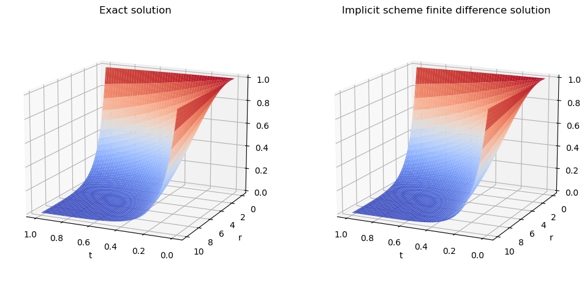

```python
from matplotlib import cm

X, Y = np.meshgrid(grid_t, grid_r)

fig, ax = plt.subplots(nrows=1, ncols =  2, subplot_kw={"projection": "3d"}, figsize = (12, 6))



surf1 = ax[0].plot_surface(X, Y, ZC_exact, cmap=cm.coolwarm,
                       linewidth=0)
surf2 = ax[1].plot_surface(X,Y, ZC_fin_diff, cmap=cm.coolwarm,
                       linewidth=0)
ax[1].view_init(15, 115)
ax[1].set_zlim(0, 1)
ax[1].set_xlabel("t")
ax[1].set_ylabel("r")

ax[0].view_init(15, 115)
ax[0].set_zlim(0, 1)
ax[0].set_xlabel("t")
ax[0].set_ylabel("r")


ax[0].set_title("Exact solution")
ax[1].set_title("Implicit scheme finite difference solution")
plt.show()
```

#### 2. Price of an Asian option.

Another application of Feynman-Kac is to get a pde for the price of an Asian option whose payoff is path-dependent.

Again, consider a stock whose price follows a geometric brownian motion. An *Asian* option is a derivative security whose payoff at maturity time $T$ is:

$$ V(T) = \left(\frac{1}{T}\int_0^T S(u)du - K\right)^{+} $$

We finde the 0 time price for this type of option where the payoff involved an average of the price over a discrete set of fixed times. In this case, we have the average of the stock price over all the interval $[0, T]$. Note that the payoff $V(T)$ depends on the whole path of the stock price via the integral and due to this, at each time $t$ prior to expiration it is not enough to know the stock price in order to determine the value of the option, we must also know the value of the integral of the stock price up to time $t$; $Y(t)=\int_0^t S(u)du$.

For the process $Y$ we have the sde $dY(u) = S(u)du$, then together with the sde for the stock price, we have the system of sde's:

$$ \begin{align*} dS(u) =& rS(u)du + \sigma S(u)d\widetilde{W}(u)\\ dY(u) =& S(u)du \end{align*} $$

or equivalently

$$ dX(u) = \begin{pmatrix} r & 0\\ 1 & 0\end{pmatrix} X(u)du +\begin{pmatrix} \sigma & 0\\ 0 & 0\end{pmatrix} X(u)d\widetilde{W}(u)\quad \text{with } X(u) =(S(u), Y(u))^T $$

Then the two dimensional process $(S(u), Y(u))$ has the Markov property. Note that $Y$ itself is not Markov. Then, starting at time zero with $S(0)>0,~ Y(0)=0$, the payoff of the Asian option is $V(T) = \left(\frac{1}{T}Y(T) - K \right)^{+}$. By the risk-neutral pricing formula, the value of this option at time $t$ is simply the expected discounted payoff:

$$ V(t) =\widetilde{\mathbb{E}}\left[e^{-r(T-t)}V(T)\vert \mathcal{F}(t)\right], \quad t\in[0, T] $$

Then, by (multi-dimensional) Feynman-Kac Theorem, there exists a fuction $v(t, x, y)$ such that

$$ v(t, S(t), Y(t))= V(t) $$

with $v(T, x, y) = \left(\frac{y}{T}-K\right)^{+}$. The function $v$ must satisfy a pde. In fact, by the (local) Martingale property of the process $e^{-rt}v(t, S(t), Y(t))$ the term multiplying $dt$ in $d(v(t, S(t), Y(t)))$ must be zero:

$$ \begin{align*} d(e^{-rt}&v(t, S(t), Y(t))) \\ &= e^{-rt}\left(-rvdt + v_{t}dt + v_{x}dS(t) + v_{y}dY(t) + \frac{1}{2}v_{xx}dS(t)dS(t) + v_{xy}dS(t)dY(t) +\frac{1}{2}v_yydY(t)dY(t)\right) \end{align*} $$

Since $$ dY(t)dY(t) = S^{2}(t)dt*dt =0,\quad dS(t)dY(t) = (\cdots)dt*dt + (\cdots)dt*d\widetilde{W}(t) = 0,\quad dS(t)dS(t) = \sigma^2 S^2(t) dt $$

then:

$$ \begin{align*} d(e^{-rt}&v(t, S(t), Y(t))) &= e^{-rt}\left(-rvdt + v_{t}dt + v_{x}(rS(t)dt + \sigma S(t) d\widetilde{W}(t)) + v_{y}S(t)dt + \frac{1}{2}v_{xx}\sigma^2S^2(t) dt + \right) \end{align*} $$

By equating the $dt$ coefficient to zero and for all $S(t), Y(t)$ we get:

$$ \begin{align*} \begin{cases} &v_{t}(t,x,y)+ + \frac{1}{2}\sigma^2 x^2v_{xx} + rxv_{x}(t, x,y) + xv_{y}(t,x,y) = rv(t, x,y)\\ \\ &v(T, x, y) = \left(\frac{y}{T}-K\right)^{+} \end{cases} \end{align*} $$